[figure not shown]

[figure not shown]

[figure not shown]

# EDA

Exploratory Data Analysis

## What is the effect of various factors of a song on its popularity and how do ensemble methods vs. neural network perform on predicting a song’s popularity?

### Song Popularity Dataframe

|  | X | title | artist | top.genre | year | bpm | nrgy | dnce | dB | live | val | dur | acous | spch | pop |
| --- | --- | --- | --- | --- | --- | --- | --- | --- | --- | --- | --- | --- | --- | --- | --- |
| 1 | 1 | Hey, Soul Sister | Train | neo mellow | 2010 | 97 | 89 | 67 | -4 | 8 | 80 | 217 | 19 | 4 | 83 |
| 2 | 2 | Love The Way You Lie | Eminem | detroit hip hop | 2010 | 87 | 93 | 75 | -5 | 52 | 64 | 263 | 24 | 23 | 82 |
| 3 | 3 | TiK ToK | Kesha | dance pop | 2010 | 120 | 84 | 76 | -3 | 29 | 71 | 200 | 10 | 14 | 80 |
| 4 | 4 | Bad Romance | Lady Gaga | dance pop | 2010 | 119 | 92 | 70 | -4 | 8 | 71 | 295 | 0 | 4 | 79 |
| 5 | 5 | Just the Way You Are | Bruno Mars | pop | 2010 | 109 | 84 | 64 | -5 | 9 | 43 | 221 | 2 | 4 | 78 |
| 6 | 6 | Baby | Justin Bieber | canadian pop | 2010 | 65 | 86 | 73 | -5 | 11 | 54 | 214 | 4 | 14 | 77 |
| 7 | 7 | Dynamite | Taio Cruz | dance pop | 2010 | 120 | 78 | 75 | -4 | 4 | 82 | 203 | 0 | 9 | 77 |
| 8 | 8 | Secrets | OneRepublic | dance pop | 2010 | 148 | 76 | 52 | -6 | 12 | 38 | 225 | 7 | 4 | 77 |
| 9 | 9 | Empire State of Mind (Part II) Broken Down | Alicia Keys | hip pop | 2010 | 93 | 37 | 48 | -8 | 12 | 14 | 216 | 74 | 3 | 76 |
| 10 | 10 | Only Girl (In The World) | Rihanna | barbadian pop | 2010 | 126 | 72 | 79 | -4 | 7 | 61 | 235 | 13 | 4 | 73 |

### Correlation Matrix for Features

|  | X | year | bpm | nrgy | dnce | dB | live | val | dur | acous | spch | pop |
| --- | --- | --- | --- | --- | --- | --- | --- | --- | --- | --- | --- | --- |
| X | 1 | 0.9890313901476274 | -0.1148488330711624 | -0.2145859804196874 | 0.07491971734097408 | -0.133913865676853 | -0.1298651377347997 | -0.1290023004983421 | -0.2107828042151615 | 0.09651790213554555 | 0.01367198457465649 | 0.1504202851129725 |
| year | 0.9890313901476274 | 1 | -0.1042471370161811 | -0.2255962058425048 | 0.07926877357952254 | -0.1264709710183576 | -0.1363311927324046 | -0.1220251442203173 | -0.2153436195905015 | 0.1017251659189527 | 0.004778381552524393 | 0.241261136995113 |
| bpm | -0.1148488330711624 | -0.1042471370161811 | 1 | 0.1261700649431025 | -0.131300671041989 | 0.1838698291201746 | 0.08157927768549561 | 0.0160209433490256 | -0.02935907390943197 | -0.1132567649680258 | 0.05899880322391054 | 0.01898298213263352 |
| nrgy | -0.2145859804196874 | -0.2255962058425048 | 0.1261700649431025 | 1 | 0.1672089266041695 | 0.5375280390654407 | 0.1867376066685157 | 0.409577297161054 | -0.1436102026495315 | -0.5622874424326889 | 0.1073134457571079 | -0.05764503617766648 |
| dnce | 0.07491971734097408 | 0.07926877357952254 | -0.131300671041989 | 0.1672089266041695 | 1 | 0.2331700569297262 | -0.02880145162081642 | 0.5016961890764099 | -0.1768408720029769 | -0.240064016507588 | -0.02804130521521662 | 0.116054444614421 |
| dB | -0.133913865676853 | -0.1264709710183576 | 0.1838698291201746 | 0.5375280390654407 | 0.2331700569297262 | 1 | 0.08193404726745876 | 0.2829218687568014 | -0.1047234168036115 | -0.1904010702555812 | -0.001109512685375108 | 0.1568972163250782 |
| live | -0.1298651377347997 | -0.1363311927324046 | 0.08157927768549561 | 0.1867376066685157 | -0.02880145162081642 | 0.08193404726745876 | 1 | 0.02022604589949669 | 0.09833929181199255 | -0.09816711336205176 | 0.1441032113125343 | -0.07574905467401427 |
| val | -0.1290023004983421 | -0.1220251442203173 | 0.0160209433490256 | 0.409577297161054 | 0.5016961890764099 | 0.2829218687568014 | 0.02022604589949669 | 1 | -0.2622557298954812 | -0.2490382013407257 | 0.1220125878143581 | 0.03895258663575966 |
| dur | -0.2107828042151615 | -0.2153436195905015 | -0.02935907390943197 | -0.1436102026495315 | -0.1768408720029769 | -0.1047234168036115 | 0.09833929181199255 | -0.2622557298954812 | 1 | 0.09180218338638158 | 0.05456351106611326 | -0.1043627531548553 |
| acous | 0.09651790213554555 | 0.1017251659189527 | -0.1132567649680258 | -0.5622874424326889 | -0.240064016507588 | -0.1904010702555812 | -0.09816711336205176 | -0.2490382013407257 | 0.09180218338638158 | 1 | 0.002762547324119206 | 0.02670353364616184 |

[output cut: 2 more lines]

# EDA Continued

Deleting negative correlations columns shown in correlation matrix and columns 1 and 2 (X and title) resulted in lowest RMSE

One-hot encoded columns. This converted the categorical columns to numerical. For example, the artist column.

```
  year bpm dnce dB val acous spch pop
1 2010  97   67 -4  80    19    4  83
2 2010  87   75 -5  64    24   23  82
3 2010 120   76 -3  71    10   14  80
4 2010 119   70 -4  71     0    4  79
5 2010 109   64 -5  43     2    4  78
6 2010  65   73 -5  54     4   14  77
  title_...Ready For It? - BloodPop\xae Remix title_#Beautiful title_#SELFIE
1                                           0                0             0
2                                           0                0             0
3                                           0                0             0
4                                           0                0             0
5                                           0                0             0
6                                           0                0             0
  title_#thatPOWER
1                0
2                0
3                0
4                0
5                0
6                0
```

Top 10 List of Features for Song Popularity

```
                               year                       top.genre_pop
                          0.2412611                           0.1904908
              artist_Martin Solveig              title_L.A.LOVE (la la)
                          0.1869046                           0.1869046
      title_Blow Me (One Last Kiss)             title_Million Years Ago
                          0.1869046                           0.1869046
              title_Not a Bad Thing title_Muny - Album Version (Edited)
                          0.1869046                           0.1672366
                top.genre_dance pop                                  dB
                          0.1618429                           0.1568972
```

# Best Features

### Best Feature 1: Year

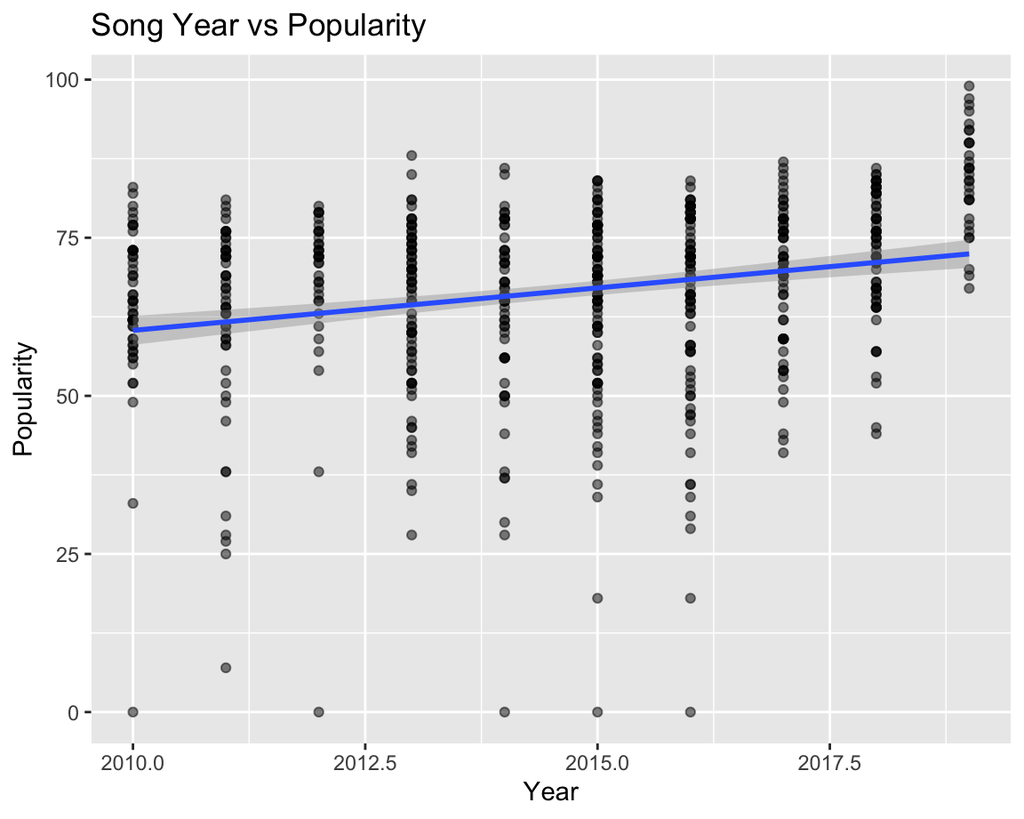

### Best Feature 10: dB

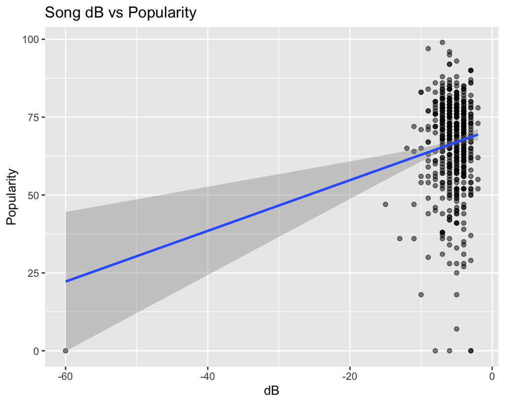

# Model Comparison: Random Forest Vs. Neural Network

| Random Forest RMSE |
| --- |
| `[1] 13.303` |

Neural Network (Adam Optimizer, 20 epochs)

Overfitting not observed in neural network because rmse for test set was lower than train set.

```
A `luz_module_evaluation`
── Results ─────────────────────────────────────────────────────────────────────
loss: 201.3435
rmse: 14.2492
```

# Neural Network Plot and Results

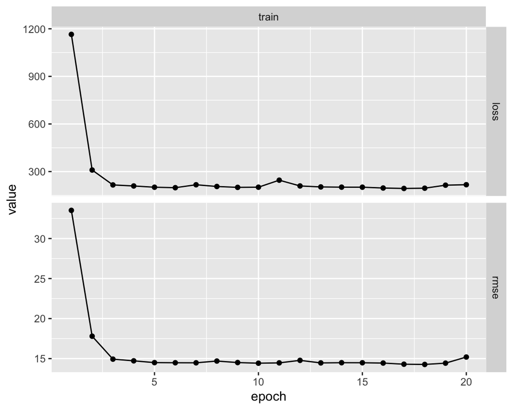

### Results

Of the 10 features that correlated most with a song popularity, the year, artist, title, and dB of a song contributed most to a song’s popularity. For model comparison, the ensemble method (Random Forest) achieved a lower RMSE than the neural network. The Random Forest achieved a lower RMSE than the neural network by roughly 1 point. This was due to the Random Forest better at capturing the non-linear relationships.